# Housing Market Dynamics

From PCA to Factor Models

Yiran Yao

2025-08-04

# Introduction

Traditional approaches to analysing housing indexes, such as hedonic or repeat-sales models, can introduce selection bias or violate underlying assumptions. Moreover, they fail to capture key regional, social, or macroeconomic factors that play a significant role in driving housing price movements.

In the recent research Sijp et al. (2025) propose a new approach that applies Principal Component Analysis (PCA) to regional SA4 level housing indexes, enabling the extraction of key drivers of price movements and offering a deeper understanding of the forces shaping housing markets.

The PCA results show that the first three principal components capture much of the behaviour of local price indexes, as a linear combination of their time series explains most of the variance in the housing index. Nevertheless, the PCA-based linear model lacks robustness across different time windows, and its coefficient estimates must be derived directly from the PCA procedure.

Our exploratory research extends the PCA approach by addressing these limitations through a factor linear model, which uses time series data directly, with independent variables serving as proxies for the PCA-derived principal components.

# Moving from PCA to Factor Model

The national trend (U) exhibits a close correspondence with PC1 (market), while the Perth–Sydney spread (δPS) aligns with PC2 (mining). Given that these principal components account for the majority of variance in the index, our preliminary analysis focuses on U and δPS, with subsequent extensions planned. (WIP - might add lifestyle)

We examined whether PC2 is better represented by the Brisbane–Sydney or Perth–Sydney spread by comparing the shapes of the standardised series and testing their correlations with PC2. The Perth–Sydney spread aligns more closely with PC2: The scatterplot shows a distribution that falls more evenly along the regression line, and its correlation with PC2 is slightly higher (98% versus 96% for the Brisbane–Sydney spread). While the difference is minor and not statistically significant, the Perth–Sydney spread is the stronger candidate as a proxy for PC2.

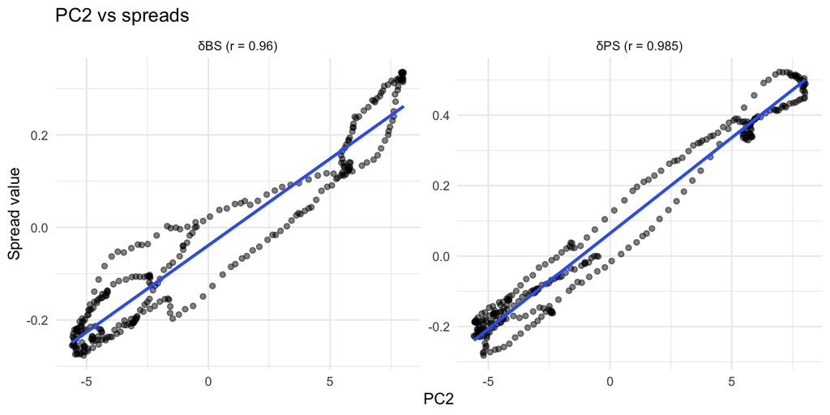

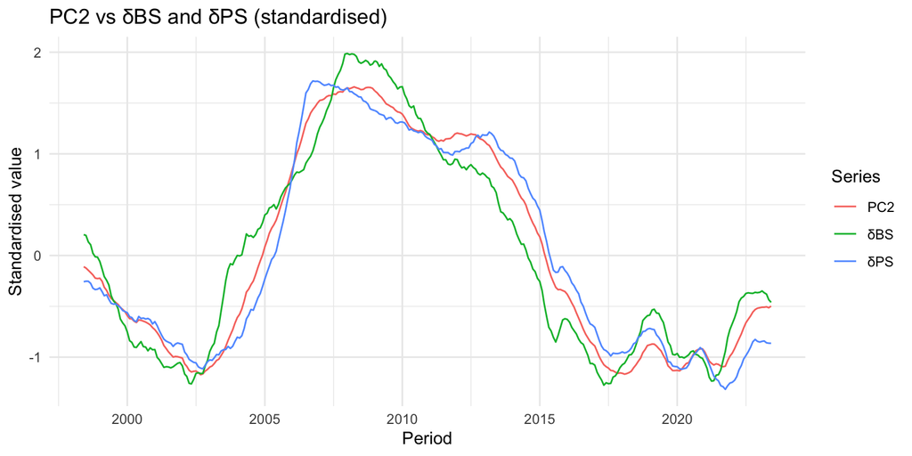

## Data Source and Limitaions (WIP)

# Exploratory Analysis

The exploratory analysis utilises visualisations to characterise the dynamics of the national trend (U) and the Perth–Sydney spread (δPS), thereby clarifying their underlying properties.

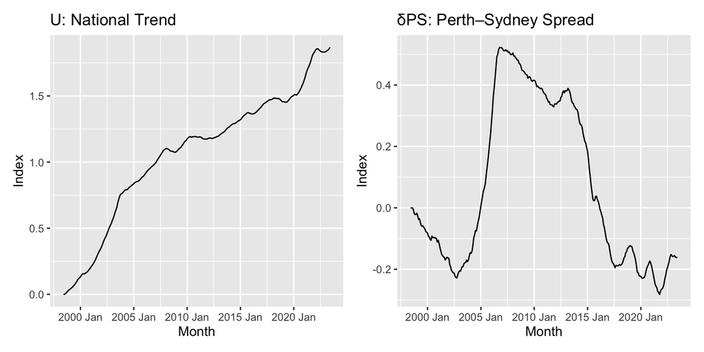

**Time-series plots:**

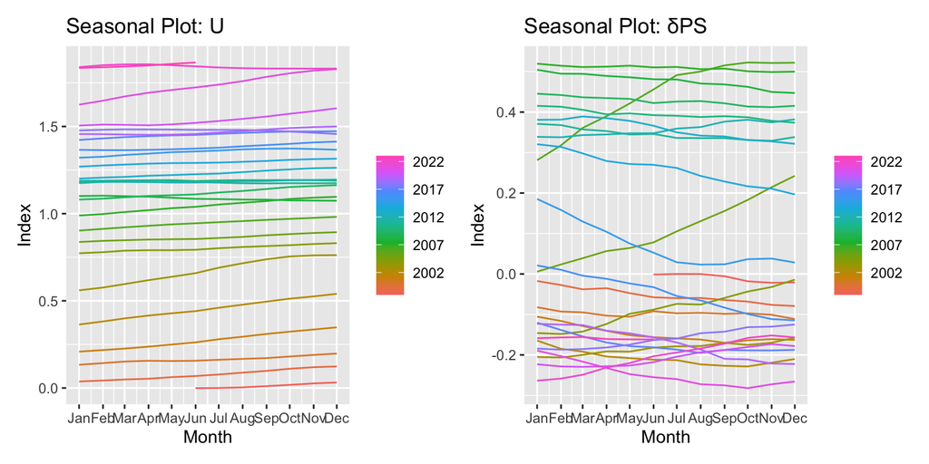

**Seasonal plots:**

- U has apparent within-year slopes being dominated by the strong upward trend; no systematic month-of-year effects.
- δPS shows little evidence of month-to-month seasonality, with no particular month standing out, though its overall level varies between years.

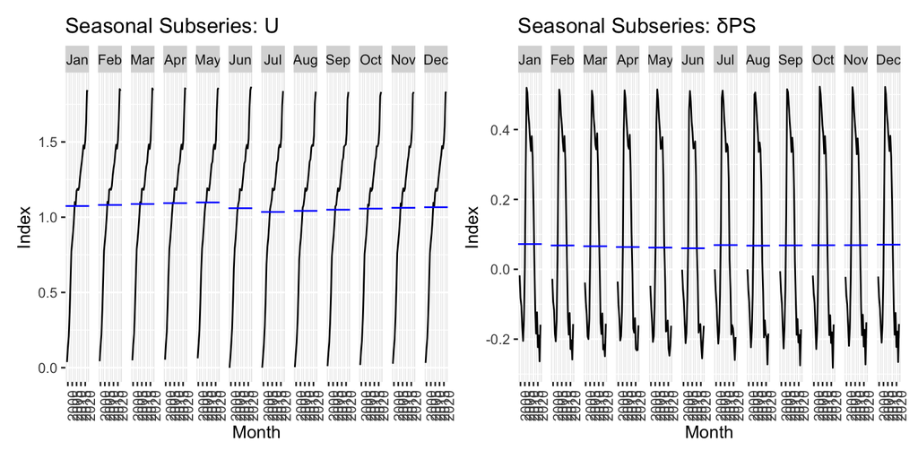

**Seasonal sub-series plot:**

- Each monthly panel of U shows a steady upward rise with mean value across months remaining similar, reinforcing that the series is driven more by trend than by seasonality.
- The δPS seasonal sub-series plot reinforces the lack of a dominant seasonal pattern, as the monthly profiles are similar in shape and the corresponding means remain relatively flat and close to zero.

# Forecasting with the Factor Model

With the factors now established, we proceed to fit time series forecasting models to each series individually. As a first step, we examine the series in more detail. STL decomposition plots allow us to closely inspect the trend, seasonality, and remainder components, which helps determine the most suitable forecasting models for the series’ characteristics.

Stationary tests (ADF and KPSS) indicate that both the national index (U) and the Perth–Sydney spread (PS) are non-stationary, so differencing is required. However, based on economic intuition that the PS series may be mean-reverting, we applied the Zivot–Andrews (ur.za) test. This confirmed that PS could be stationary with several structural break.

The dataset was partitioned into training and testing subsets, with one year of observations allocated to the testing set. Given that the data are recorded at a monthly frequency and span only 25 years, this allocation represents an optimal balance between ensuring sufficient data for model training while preserving an adequate sample for evaluation.

## National Trend

The STL decomposition of the national trend U reveals a smooth and persistent upward trajectory in the trend component, while the seasonal component is of relatively minor magnitude, however the annual seasonality is strong and repeating. To stabilise variation in the seasonal component, a Box–Cox transformation was applied using the Guerrero method, which produced a λ value of 0.9. Given its proximity to one, the transformation had a negligible effect on the modelling outcome. The remainder component displays mostly small noise, with some bigger shocks.

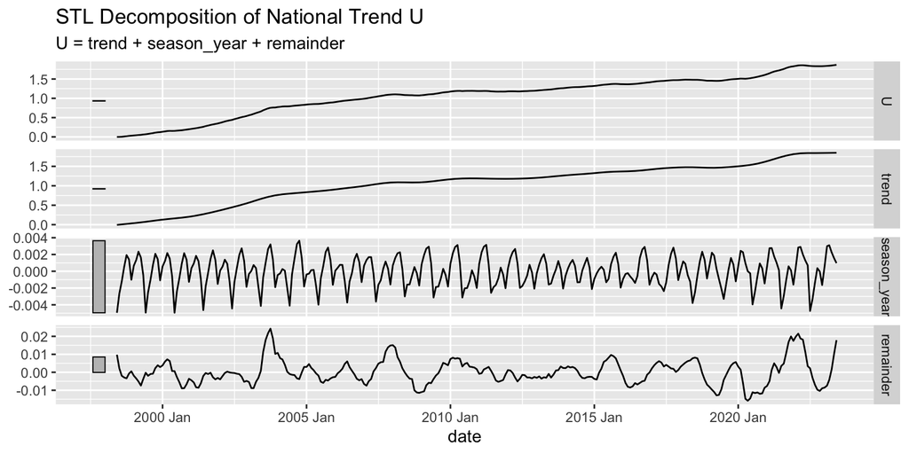

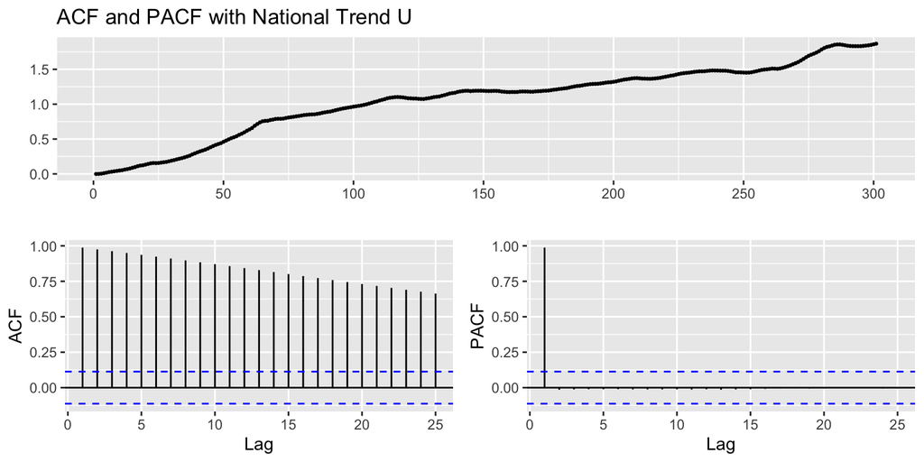

The modelling strategy was guided by exploratory data analysis and the STL decomposition, which suggested a random walk with drift, `ARIMA(U ∼ pdq(0,1,0))`, as an appropriate baseline specification.

To refine the model, we subsequently evaluated neighbouring specifications with alternative autoregressive and moving average terms, using AICc values and residual diagnostics as selection criteria.

In the modelling process, we evaluated a range of specifications informed both by diagnostic checks and prior knowledge. Inspection of the residuals suggested some semi-annual variation, and Fourier terms with `K = 2` were added to account for potential higher-frequency seasonality. We also investigated seasonal extensions with `P = 1`, alongside piecewise specifications with knots aligned to major economic events: the Global Financial Crisis (2008), the end of the mining investment boom (2012), and the onset of the COVID-19 pandemic (2020). These variations were assessed with respect to residual behaviour, statistical significance, and their ability to capture shocks apparent in the remainder component.

Among the fitted models, two candidates emerged as particularly strong. The first, an ARIMA(2,1,1) with Fourier terms (K = 2) and drift. A second competitive specification combined Fourier terms (K = 2) with intervention dummies (step and pulse) and an ARIMA(2,1,1) structure.

```
## # A tibble: 8 × 8
##   .model        sigma2 log_lik    AIC   AICc    BIC ar_roots   ma_roots
##   <chr>          <dbl>   <dbl>  <dbl>  <dbl>  <dbl> <list>     <list>
## 1 step      0.00000672   1338. -2650. -2649. -2602. <cpl [26]> <cpl [1]>
## 2 arima211  0.00000700   1331. -2640. -2639. -2599. <cpl [26]> <cpl [1]>
## 3 arima110  0.00000712   1327. -2637. -2636. -2604. <cpl [25]> <cpl [0]>
## 4 arima111  0.00000715   1327. -2635. -2634. -2598. <cpl [25]> <cpl [1]>
## 5 sarima211 0.00000785   1312. -2611. -2611. -2589. <cpl [14]> <cpl [1]>
## 6 autoarima 0.00000774   1308. -2609. -2609. -2598. <cpl [24]> <cpl [0]>
## 7 piece     0.00000791   1312. -2606. -2606. -2573. <cpl [1]>  <cpl [25]>
## 8 rw_drift  0.0000416    1066. -2127. -2127. -2116. <cpl [0]>  <cpl [12]>
```

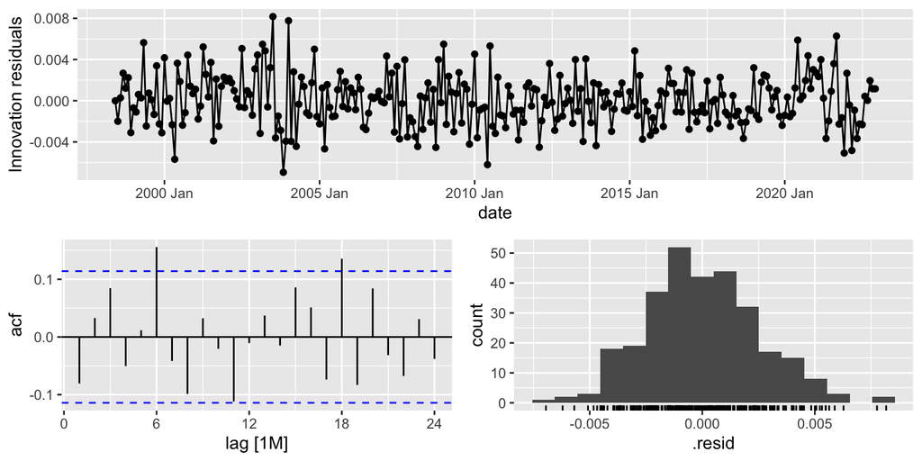

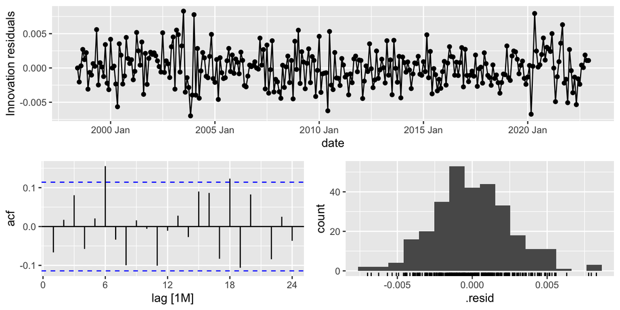

```
## # A tibble: 8 × 3
##   .model    lb_stat lb_pvalue
##   <chr>       <dbl>     <dbl>
## 1 arima211     18.4   0.103
## 2 step         20.4   0.0595
## 3 sarima211    21.7   0.0411
## 4 autoarima    23.0   0.0279
## 5 arima110     24.7   0.0165
## 6 arima111     24.8   0.0157
## 7 piece        28.9   0.00411
## 8 rw_drift    885.    0
```

## Mining Trend

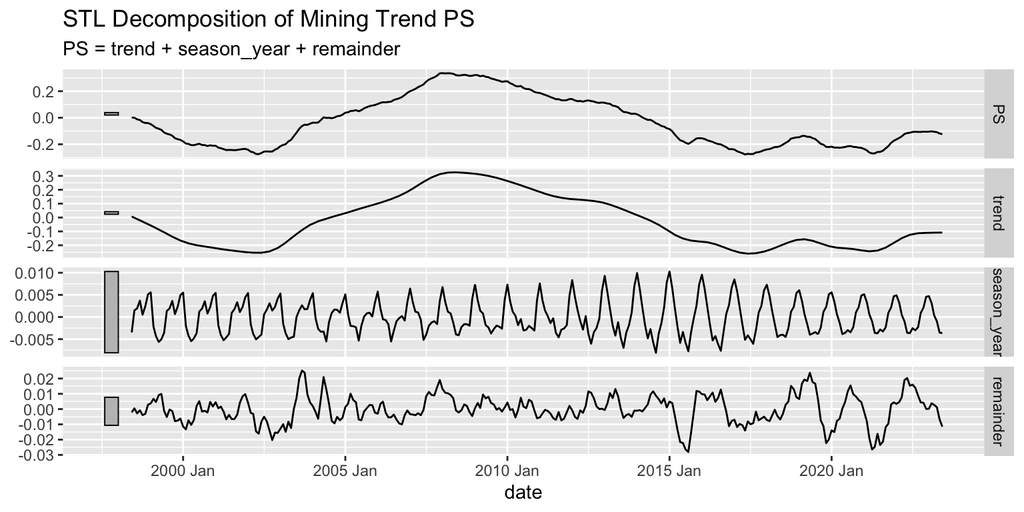

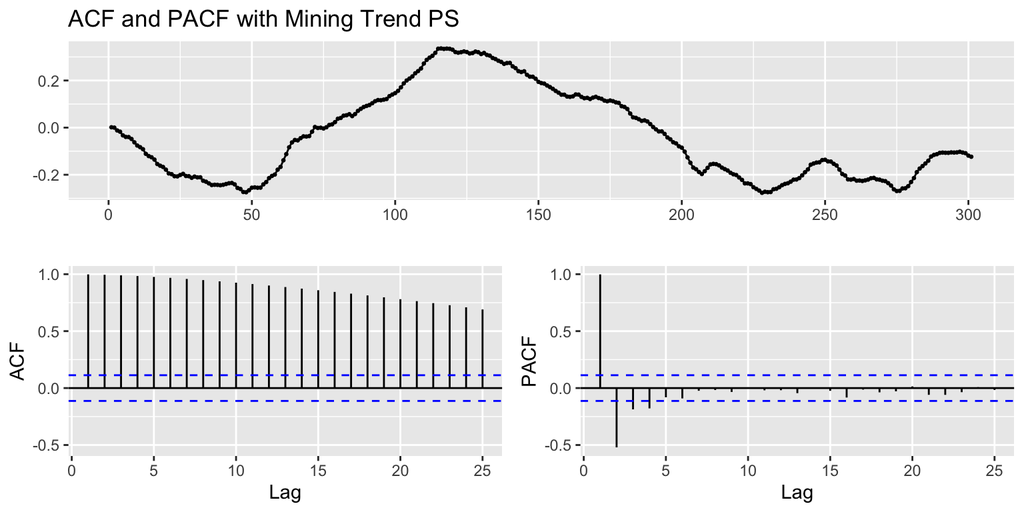

We experimented with several models for this series. First, we used a robust STL decomposition to separate the seasonal component from the low-frequency movement, then modelled the seasonally adjusted series with a simple ARIMA while allowing seasonality to be captured by a seasonal naïve. Introducing a single difference in the short-memory component produced a stable fit and whitened residuals.

Since earlier analysis suggested the series could be rendered stationary by accounting for structural breaks, we explored two additional approaches. The first was an ARFIMA model, where deterministic seasonality and a known 2011 level shift were removed before estimating the fractional differencing parameter d. With `d < 0.5`, this indicated that full first-differencing may not be required. Finally, we de-seasonalised with STL, identified level breaks, introduced six step dummies at the detected dates, and captured the remaining short-memory with an ARMA specification on the regression residuals, which satisfied the Ljung–Box test for whiteness.

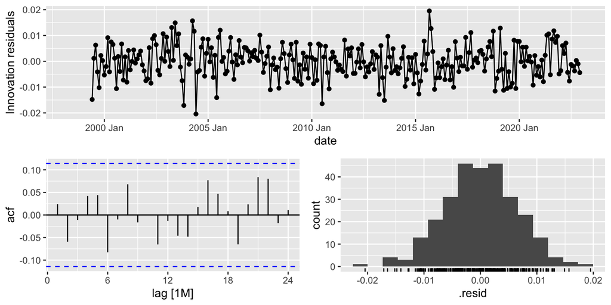

```
## # A tibble: 1 × 3
##   .model lb_stat lb_pvalue
##   <chr>    <dbl>     <dbl>
## 1 stl       16.7     0.730
```

```
##
##  Box-Ljung test
##
## data:  residuals(fit_PS2)
## X-squared = 9.2579, df = 24, p-value = 0.997
```

```
##
##  Box-Ljung test
##
## data:  residuals(m_ma1)
## X-squared = 35.291, df = 24, p-value = 0.06421
```

## Forecast Performance

(WIP - on the PS fan width is too wide - will re-examine the model)

```
## # A tibble: 1 × 3
##   .model   width80_range width95_range
##   <chr>            <dbl>         <dbl>
## 1 arima211         0.678          1.04
```

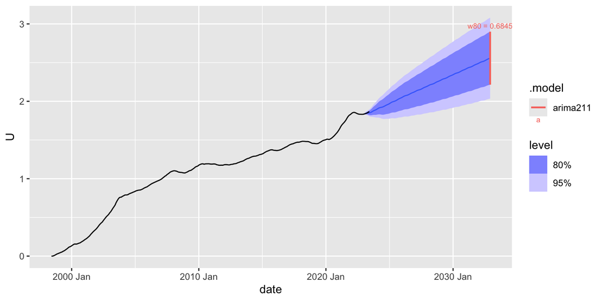

```
## # A tibble: 1 × 3
##   .model width80_range width95_range
##   <chr>          <dbl>         <dbl>
## 1 stl            0.916          1.40
```

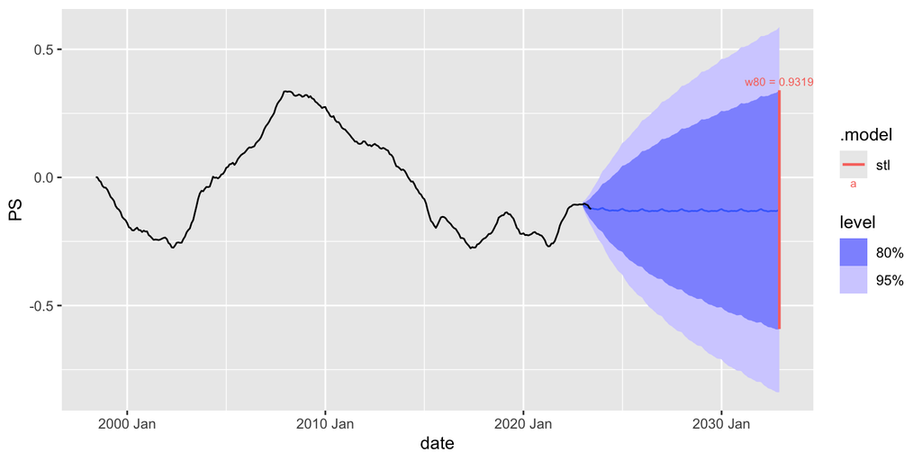

## Factor Model Application on Major City and SA4 Regions

### Goodness of Fit

We now turn to evaluating how well the factor model captures the variation in individual major city and SA4 indexes. R² measures the share of variation in each major city or SA4 housing index that our factor model explains.

**For major cities and rest-of-state:** Most city and regions have an R² value above 0.98. The extremes highlight clear spatial patterns:

- Top cities and rest-of-state: Large east-coast capitals and their surrounding belts.
- Bottom cities and rest-of-state: Smaller or resource-dependent markets.

Top 5 and Bottom 5 Major City and Area by R²

| Top 5 Rank | Top 5 Region | Top 5 R² | Bottom 5 Rank | Bottom 5 Region | Bottom 5 R² |
| --- | --- | --- | --- | --- | --- |
| 1 | GREATER MELBOURNE | 0.9985 | 15 | REST OF WA | 0.9697 |
| 2 | REST OF NSW | 0.9985 | 14 | GREATER PERTH | 0.9735 |
| 3 | REST OF QLD | 0.9983 | 13 | REST OF NT | 0.9800 |
| 4 | GREATER SYDNEY | 0.9981 | 12 | GREATER HOBART | 0.9857 |
| 5 | GREATER BRISBANE | 0.9979 | 11 | GREATER DARWIN | 0.9860 |

**For SA4 regions**: The SA4 regions shares the same stories. R² is tightly concentrated near 1.0 with the majority of SA4s exceed 0.98, with only a small left tail (a few around 0.92 – 0.95). The top and bottom lists identify the extremes and show recurring patterns across those regions:

- Top 10 regions: Concentrated in the large east-coast capitals and surrounding belts.
- Bottom 10 regions : Dominated by Western Australia and Queensland’s mining exposed regions.

Top 10 and Bottom 10 SA4 Regions by R²

| Top 10 Rank | Top 10 Region | Top 10 R² | Bottom 10 Rank | Bottom 10 Region | Bottom 10 R² |
| --- | --- | --- | --- | --- | --- |
| 1 | MELBOURNE - SOUTH EAST | 0.9982 | 87 | WESTERN AUSTRALIA - OUTBACK (NORTH) | 0.9184 |
| 2 | MELBOURNE - OUTER EAST | 0.9979 | 86 | MANDURAH | 0.9460 |
| 3 | BRISBANE - WEST | 0.9975 | 85 | WESTERN AUSTRALIA - OUTBACK (SOUTH) | 0.9601 |
| 4 | BRISBANE - SOUTH | 0.9974 | 84 | BUNBURY | 0.9606 |
| 5 | BRISBANE - NORTH | 0.9974 | 83 | WESTERN AUSTRALIA - WHEAT BELT | 0.9635 |
| 6 | ADELAIDE - WEST | 0.9972 | 82 | MACKAY - ISAAC - WHITSUNDAY | 0.9678 |
| 7 | MELBOURNE - NORTH EAST | 0.9972 | 81 | PERTH - SOUTH EAST | 0.9691 |
| 8 | ADELAIDE - CENTRAL AND HILLS | 0.9972 | 80 | PERTH - NORTH EAST | 0.9695 |
| 9 | SYDNEY - BAULKHAM HILLS AND HAWKESBURY | 0.9970 | 79 | PERTH - SOUTH WEST | 0.9732 |
| 10 | WIDE BAY | 0.9970 | 78 | CENTRAL QUEENSLAND | 0.9743 |

Both SA4 regions and major cities display highly concentrated R² distributions with major cities showing less variation.

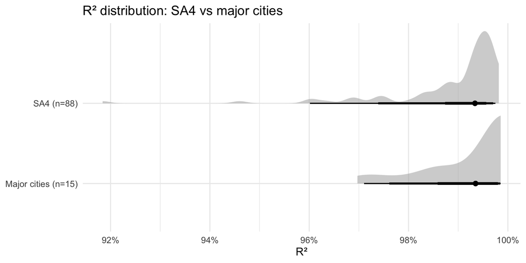

Hence, we’ll prioritise Western Australia and Queensland’s mining-exposed regions for residual diagnostics, where we expect autocorrelation and regime shifts for trial enhancements.

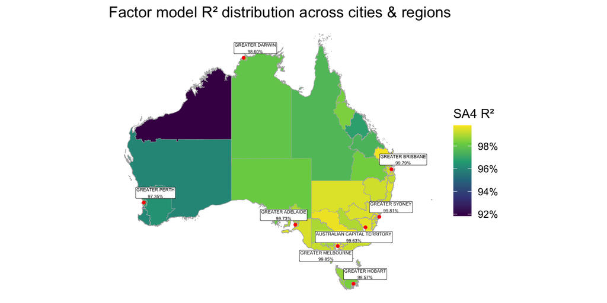

### Residual Autocorrelation

At this stage, the model does not incorporate any time dynamics in the residuals. While it explains a substantial share of the variance for both cities and regions, the trending and autocorrelated nature of housing indexes means that the residuals themselves display extremely strong positive autocorrelation. This is evident in the Durbin–Watson statistics, which are close to zero across all regions: Major cities cluster around 0.02 to 0.05, while SA4 regions have a slightly broader range, extending up to 0.2, but still remain far below the benchmark value of 2. This pattern underscores the limitations of using a static regression framework without accounting for time-series dynamics.

```
## # A tibble: 2 × 6
##   region_level dw_min dw_max dw_mean dw_median  range
##   <chr>         <dbl>  <dbl>   <dbl>     <dbl>  <dbl>
## 1 major_city   0.0146  0.104  0.0338    0.0282 0.0891
## 2 sa4_name     0.0211  0.201  0.0680    0.0598 0.180
```

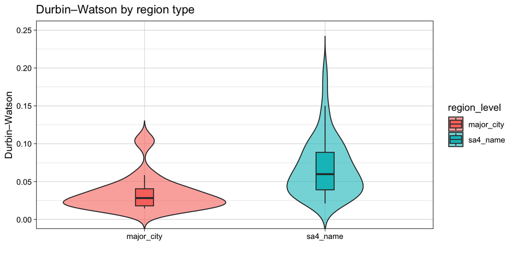

## Coefficient Pattern

While R² and Durbin–Watson assess overall fit and residual behaviour, they do not show how regions load onto each factor. Examining coefficient patterns adds this context, revealing whether markets move uniformly with the national trend or diverge due to mining influences.

The distribution of market coefficients is tightly centred around 1.0 with relatively little variation. This indicates that most regions respond in a similar way to the national housing trend. In contrast, the mining coefficients are far more dispersed with a long right tail and several extreme outliers, suggesting that exposure to mining-related dynamics differs substantially across regions.

The scatterplot analysis reveals a clear negative relationship between the market and mining coefficients. Regions with a strong loading on the national market factor tend to exhibit weaker or even negative loadings on the mining factor and vice versa.

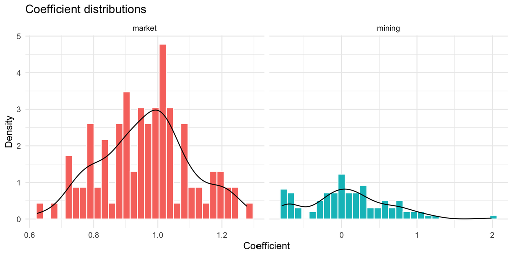

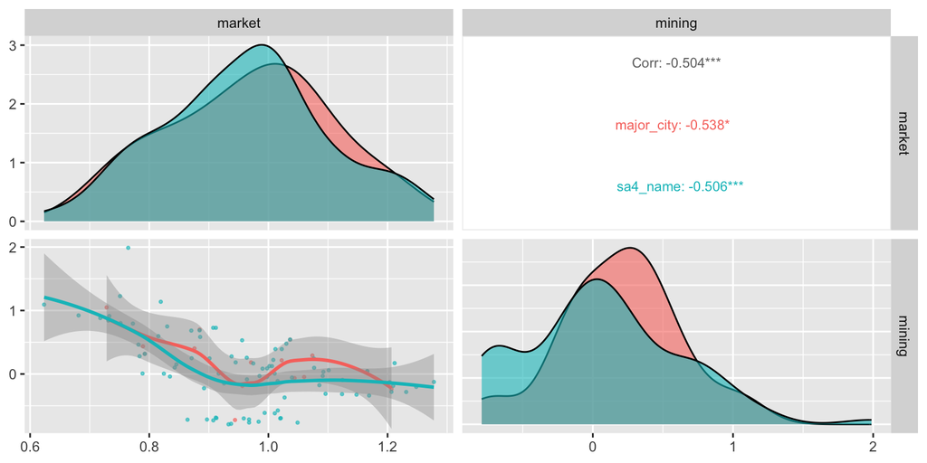